# Network Analysis - Tidyverse

jy

2021-09-25

## Intro

Notes from DataCamp course [‘Network Analytics with Tidyverse’](https://learn.datacamp.com/courses/network-analysis-in-the-tidyverse)

### Other References

- [Network Analytics with R blogpost](https://www.jessesadler.com/post/network-analysis-with-r/)

### Key Concepts 01

Networks are comprised of:

- **Nodes** (aka vertices, points): the ‘things’ in the network
  - must be identified by unique id
- **Edges** (aka links, ties): the connections between the things
  - can be directed or undirected relationships between the nodes
  - edge can have attributes
  - attributes can be used in weighting

Key packages in R for network analysis:

- igraph: network data manipulation and diagrams.
- ggraph: extends ggplot for network-relevant dimensions.
- visNetwork: interactive network diagrams.
- networkdata: ton of network datasets for exploration, demonstration, learning.

Where does tidyverse come in?

- Tidyverse concepts can be applied to network analysis and are sometimes integrated into other network analysis systems.

Where does igraph come in?

igraph is designed for organizing and working graph objects. Once a network is set up as igraph object, we can work with it in various ways, and this course is mainly about using igraph objects with tidyverse.

### igraph data/setup

The course uses data on terrorist network involved in Madrid train bombing. I was able to obtain network data on the same group via networkdata package - it is identified there as ‘covert_30’. [detail doc here](https://www.rdocumentation.org/packages/networkdata/versions/0.1.4/topics/covert_30)

```r
## madrid train bombing terrorist network data
madrid <- covert_30
## list of 25 igraph objects, based on different characteristics of the network
## can get info on all the igraph objects by subsetting the list:

#madrid[1:25] ## to look at them all

## or individual ones by:
madrid[[25]]
```

```
## IGRAPH 03db05c UNW- 54 226 -- MADRID_TIE_YEAR
## + attr: name (g/c), name (v/c), weight (e/n)
## + edges from 03db05c (vertex names):
##  [1] 3100--3101 3100--3104 3100--3106 3100--318  3100--3133 3100--3135
##  [7] 3104--3106 3104--318  3104--3133 3104--3138 3106--318  3106--3138
## [13] 3106--3132 3106--3136 3135--3138 3135--3132 3135--3136 3135--3142
## [19] 3135--3143 3135--3157 3135--3179 3138--3132 3138--3136 3138--3140
## [25] 3138--3141 3138--3142 3138--3143 3138--3145 3138--3147 3138--3180
## [31] 3138--3153 3138--3154 3138--3178 3132--3136 3132--3134 3132--3137
## [37] 3132--3139 3132--3140 3132--3141 3132--3142 3132--3143 3132--3144
## [43] 3132--3145 3132--3147 3132--3148 3132--3149 3132--3150 3132--3156
## + ... omitted several edges
```

The top section provides info on the igraph object:

- IGRAPH: indicates igraph object ;)
- 03db05c: not sure, don’t think it matters
- UNW-: indicates this is ‘Undirected’, ‘Named’, Weighted’, ‘-’ not Bipartite
- MADRID_TIE_YEAR: name of the graph
- attr: attributes, dimensions, and then showing edges based on vertex names.

Can save the object with whatever name and can also:

- get list of vertices
- get list of edges
- plot the network graph (simple plot - more to come on this later…)

```r
## SAVE selected object:
madrid_25 <- madrid[[25]]
## list of vertices (V) and edges (E)
V(madrid_25)
```

```
## + 54/54 vertices, named, from 03db05c:
##  [1] 3100 3101 3104 3106 318  3133 3135 3138 3132 3136 3134 3137 3139 3140 3141
## [16] 3142 3143 3144 3145 3147 3148 3149 3150 3156 3157 3161 3162 3179 3180 3153
## [31] 3154 3178 3163 3165 3146 3152 3164 3167 3168 3169 3171 3172 3173 3181 3166
## [46] 3151 3170 3155 3160 3174 3176 3177 3158 3159
```

```r
E(madrid_25)
```

```
## + 226/226 edges from 03db05c (vertex names):
##  [1] 3100--3101 3100--3104 3100--3106 3100--318  3100--3133 3100--3135
##  [7] 3104--3106 3104--318  3104--3133 3104--3138 3106--318  3106--3138
## [13] 3106--3132 3106--3136 3135--3138 3135--3132 3135--3136 3135--3142
## [19] 3135--3143 3135--3157 3135--3179 3138--3132 3138--3136 3138--3140
## [25] 3138--3141 3138--3142 3138--3143 3138--3145 3138--3147 3138--3180
## [31] 3138--3153 3138--3154 3138--3178 3132--3136 3132--3134 3132--3137
## [37] 3132--3139 3132--3140 3132--3141 3132--3142 3132--3143 3132--3144
## [43] 3132--3145 3132--3147 3132--3148 3132--3149 3132--3150 3132--3156
## [49] 3132--3157 3132--3161 3132--3162 3132--3179 3132--3180 3136--3137
## [55] 3136--3140 3136--3142 3136--3143 3136--3156 3136--3157 3136--3161
## + ... omitted several edges
```

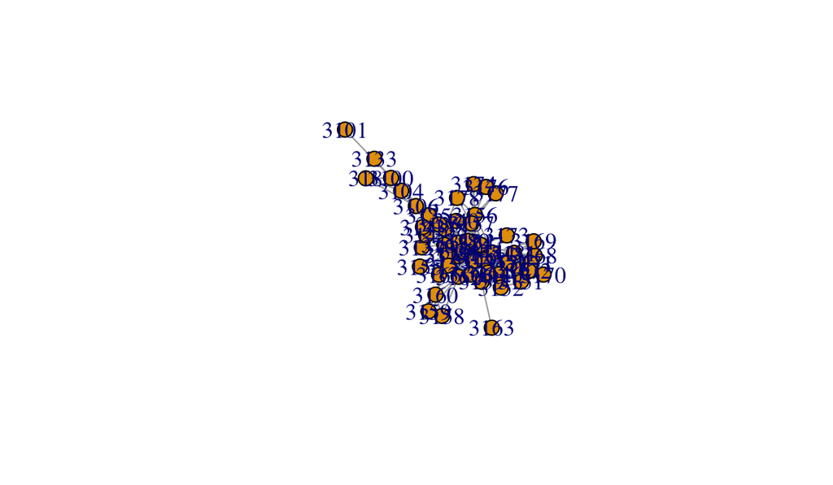

```r
## plot the network
plot.igraph(madrid_25)
```

### Tidyverse setup

#### Data frame from igraph object

For purposes of the course and working with tidyverse, we convert igraph object to data frame:

- can create data frames based on vertices, edges, or both at the same time (still two data frames)
- course uses separate vertices (nodes) and edges (ties) data frames

```r
## convert to data frame based on what= 'vertices', 'edges', 'both'
madrid_25_dfs <- get.data.frame(madrid_25, what='both')
madrid_25_dfv <- get.data.frame(madrid_25, what='vertices')
madrid_25_dfe <- get.data.frame(madrid_25, what='edges')

## for course examples:
g <- madrid_25
nodes <- madrid_25_dfv
ties <- madrid_25_dfe

head(nodes)
```

```
##      name
## 3100 3100
## 3101 3101
## 3104 3104
## 3106 3106
## 318   318
## 3133 3133
```

```r
head(ties)
```

```
##   from   to weight
## 1 3100 3101     14
## 2 3100 3104     14
## 3 3100 3106     39
## 4 3100  318     16
## 5 3100 3133     32
## 6 3100 3135     40
```